# A3: Incarceration

### Variable Comparison Chart

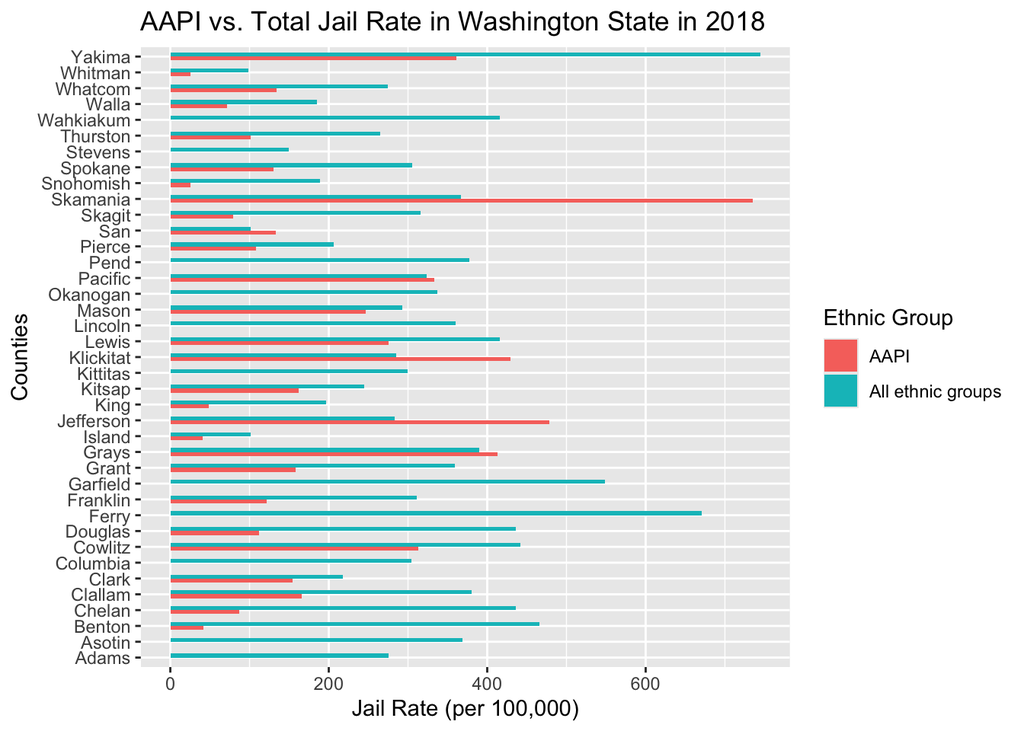

I’ve included this chart to highlight the jail rates among the AAPI population as a comparison to the overall rates in each county in WA State. Generally, across most counties, the AAPI rates are significantly lower than the overall rates. However, in a few counties, the AAPI rates exceed the overall rates, notably with a striking high in Skamania County. Organizing the counties by geographical location (e.g. West and East side), socioeconomic status, or population could offer further insights

### Map

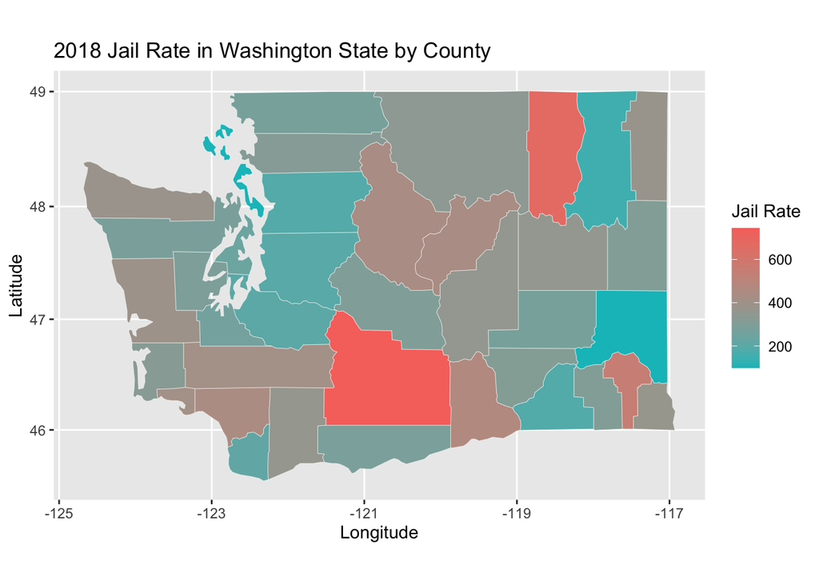

A map provides a direct and clear illustration of the geographic distribution of a variable. This map demonstrates the jail rates in every county in Washington State, revealing higher rates in Eastern Washington, with the highest rates in Yakima and Ferry counties.